# Week 6: Trajectory Generation

EE0849 Introduction to Robotics

Basri Erdogan

# Part 1: Introduction to Trajectories

## What is a Trajectory?

**Path vs Trajectory**

- **Path**: Geometric description of motion
  - Where the robot goes
  - Sequence of positions
- **Trajectory**: Path + timing
  - Where AND when
  - Positions, velocities, accelerations

[figure not shown]

## Why Trajectory Planning?

**Goals:**

1. **Smooth motion** - No jerky starts/stops
2. **Predictable timing** - Know when robot arrives
3. **Controllable dynamics** - Respect motor limits
4. **Safe operation** - Avoid excessive forces

**Constraints:**

- Maximum velocity
- Maximum acceleration
- Jerk limits (rate of acceleration change)

## Motion Types

**Point-to-Point (PTP)**

- Move from A to B
- Only endpoints matter
- Path may not be straight
- Fastest motion type

```
J P[1] 100% FINE    ; Joint motion
```

**Continuous Path (CP)**

- Follow specific path
- Interpolate between points
- Typically straight lines/arcs
- Speed may vary

```
L P[2] 500mm/sec FINE   ; Linear
C P[3] P[4] 300mm/sec FINE ; Circular
```

## Joint Space vs Cartesian Space

**Joint Space Trajectory**

- Plan in joint angles: $\theta(t)$
- Simple interpolation
- No IK needed during motion
- Path not predictable in Cartesian

[figure not shown]

**Cartesian Space Trajectory**

- Plan in $(x, y, z, \phi, \theta, \psi)$
- Predictable end-effector path
- Requires IK at each point
- May encounter singularities

[figure not shown]

# Part 2: Polynomial Trajectories

## Polynomials in Joint Space

Apply a polynomial **directly to each joint angle**:

- $\theta_1(t)$ = cubic/quintic, $\theta_2(t)$ = cubic/quintic, …
- Each joint follows a smooth profile independently
- The end-effector path in Cartesian space is generally **curved**
- This is how FANUC `J` (joint) motion works

## Polynomials in Cartesian Space

For a **straight-line** path, we separate geometry from timing:

1. **Path** (fixed shape): $\mathbf{p}(s) = \mathbf{p}_0 + s \cdot (\mathbf{p}_f - \mathbf{p}_0)$
2. **Timing** (how far along): $s(t)$ goes from 0 at the start to 1 at the end

Here $s(t)$ is just a number between 0 and 1 that says “how far along the line are we at time $t$?”

The polynomial (cubic, quintic) shapes $s(t)$, giving smooth acceleration and deceleration — while the path stays perfectly straight.

This is how FANUC `L` (linear) motion works.

## Notation for This Section

In the following slides we write $q(t)$ for the polynomial — this represents:

- A **joint angle** $\theta_i(t)$ in joint space, or
- The **progress variable** $s(t)$ in Cartesian space

The math is the same in both cases.

## The Simplest Case: Linear Interpolation

Moving from $q_0$ to $q_f$ over time $t_f$:

$$q(t) = q_0 + \frac{q_f - q_0}{t_f} \cdot t$$

**Problem**: Velocity is discontinuous!

- Velocity jumps from 0 to constant
- Jumps back to 0 at end
- Infinite acceleration!
- Motors can’t do this

[figure not shown]

## Cubic Polynomial Trajectory

**Goal**: Start and end with zero velocity

$$q(t) = a_0 + a_1 t + a_2 t^2 + a_3 t^3$$

**Boundary conditions** (4 eq, 4 unknowns):

1. $q(0) = q_0$ (start position)
2. $q(t_f) = q_f$ (final position)
3. $\dot{q}(0) = 0$ (start at rest)
4. $\dot{q}(t_f) = 0$ (final velocity zero)

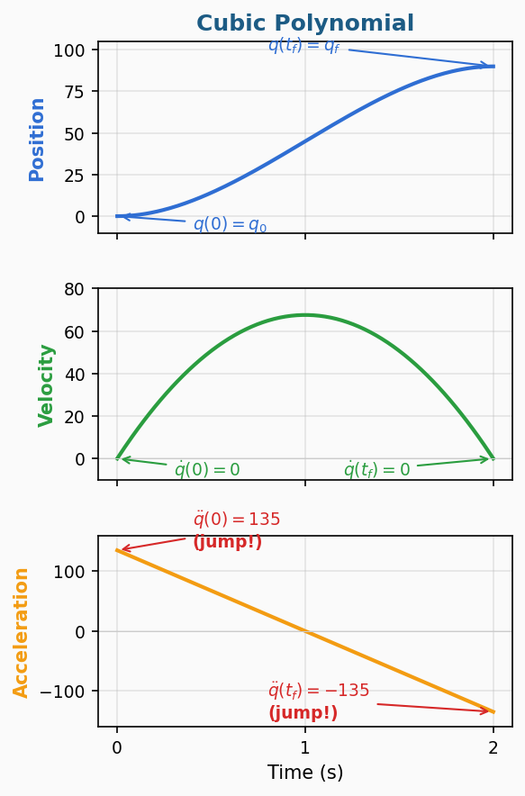

## Cubic: Apply Boundary Conditions

$$q(t) = a_3 t^3 + a_2 t^2 + a_1 t + a_0$$
$$\dot{q}(t) = 3a_3 t^2 + 2a_2 t + a_1$$

|  | $t = 0$ | $t = t_f$ |
| --- | --- | --- |
| $q$ | $q_0$ | $q_f$ |
| $\dot{q}$ | $0$ | $0$ |

**At $t = 0$:** $\quad q(0) = a_0 = q_0 \qquad \dot{q}(0) = a_1 = 0$

**At $t = t_f$:** $\quad a_3 t_f^3 + a_2 t_f^2 + a_0 = q_f \qquad 3a_3 t_f^2 + 2a_2 t_f = 0$

## Cubic: Solve for Coefficients

Write in matrix form ($a_0$ and $a_1$ are already known):

$$\begin{bmatrix} t_f^2 & t_f^3 \\ 2t_f & 3t_f^2 \end{bmatrix} \begin{bmatrix} a_2 \\ a_3 \end{bmatrix} = \begin{bmatrix} q_f - q_0 \\ 0 \end{bmatrix}$$

Invert to get:

$$a_2 = \frac{3(q_f - q_0)}{t_f^2} \qquad a_3 = \frac{-2(q_f - q_0)}{t_f^3}$$

**Final trajectory:**

$$q(t) = q_0 + \frac{3(q_f - q_0)}{t_f^2} t^2 - \frac{2(q_f - q_0)}{t_f^3} t^3$$

## Practice: Cubic Polynomial

**Problem:** Move from $q_0 = 0°$ to $q_f = 90°$ in $t_f = 2$ s with zero endpoint velocities.

1. Find the coefficients $a_0, a_1, a_2, a_3$
2. What is $q(1)$?
3. What is $\dot{q}(1)$?

**Solution:**

$a_0 = 0$, $a_1 = 0$, $a_2 = \frac{3 \times 90}{4} = 67.5$, $a_3 = \frac{-2 \times 90}{8} = -22.5$

$$q(t) = 67.5\, t^2 - 22.5\, t^3$$

- $q(1) = 67.5 - 22.5 = 45°$ (halfway — symmetric by design)
- $\dot{q}(t) = 135\,t - 67.5\,t^2 \implies \dot{q}(1) = 67.5$ °/s

## Quintic (5th Order) Polynomial

**Goal**: Also control acceleration at endpoints

$$q(t) = a_5 t^5 + a_4 t^4 + a_3 t^3 + a_2 t^2 + a_1 t + a_0$$
$$\dot{q}(t) = 5a_5 t^4 + 4a_4 t^3 + 3a_3 t^2 + 2a_2 t + a_1$$
$$\ddot{q}(t) = 20a_5 t^3 + 12a_4 t^2 + 6a_3 t + 2a_2$$

|  | $t = 0$ | $t = t_f$ |
| --- | --- | --- |
| $q$ | $q_0$ | $q_f$ |
| $\dot{q}$ | $\dot{q}_0$ | $\dot{q}_f$ |
| $\ddot{q}$ | $\ddot{q}_0$ | $\ddot{q}_f$ |

6 BCs → 6 unknowns ($a_0$ through $a_5$)

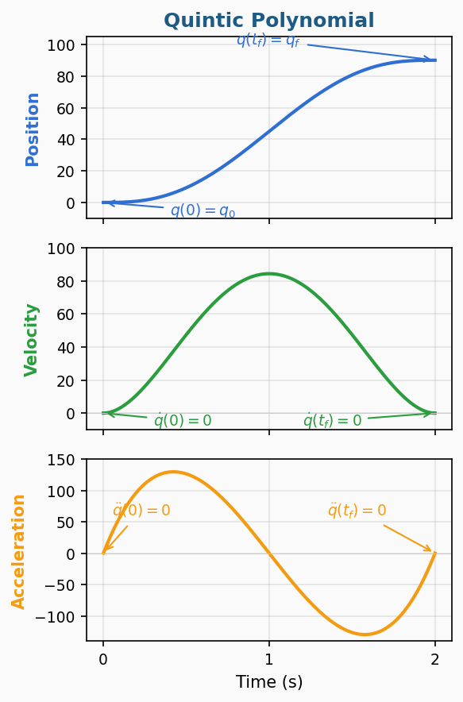

## Quintic: Apply Boundary Conditions

**At $t = 0$** (directly gives 3 coefficients):

$$a_0 = q_0 \qquad a_1 = \dot{q}_0 \qquad a_2 = \frac{\ddot{q}_0}{2}$$

**At $t = t_f$** (3 equations in 3 unknowns $a_3, a_4, a_5$):

$$\begin{bmatrix} t_f^3 & t_f^4 & t_f^5 \\ 3t_f^2 & 4t_f^3 & 5t_f^4 \\ 6t_f & 12t_f^2 & 20t_f^3 \end{bmatrix} \begin{bmatrix} a_3 \\ a_4 \\ a_5 \end{bmatrix} = \begin{bmatrix} q_f - a_0 - a_1 t_f - a_2 t_f^2 \\ \dot{q}_f - a_1 - 2a_2 t_f \\ \ddot{q}_f - 2a_2 \end{bmatrix}$$

Matrix is square → invert to solve: $\mathbf{a} = M^{-1} \mathbf{b}$

## Practice: Quintic Polynomial

**Problem:** Same move ($q_0 = 0°$, $q_f = 90°$, $t_f = 2$ s) but now with zero endpoint velocities **and** zero endpoint accelerations.

1. What are $a_0, a_1, a_2$?
2. Set up the 3×3 system for $a_3, a_4, a_5$
3. What is the peak velocity? Compare to cubic.

**Solution:**

$a_0 = 0$, $a_1 = 0$, $a_2 = 0$ (all BCs at $t=0$ are zero)

$$\begin{bmatrix} 8 & 16 & 32 \\ 12 & 32 & 80 \\ 12 & 48 & 160 \end{bmatrix} \begin{bmatrix} a_3 \\ a_4 \\ a_5 \end{bmatrix} = \begin{bmatrix} 90 \\ 0 \\ 0 \end{bmatrix} \implies a_3 = 112.5,\; a_4 = -84.375,\; a_5 = 16.875$$

Peak velocity at $t = 1$: $\dot{q}(1) = 3a_3 + 4a_4 + 5a_5 = 84.4$ °/s (vs 67.5 °/s for cubic — higher peak!)

## Python: Cubic Trajectory

```python
import numpy as np

def cubic_trajectory(q0, qf, tf, dt=0.01):
    """Generate cubic polynomial trajectory."""
    t = np.arange(0, tf + dt, dt)

    # Normalized time
    s = t / tf

    # Cubic polynomial: 3s^2 - 2s^3
    q = q0 + (qf - q0) * (3*s**2 - 2*s**3)

    # Velocity
    v = (qf - q0) * (6*s - 6*s**2) / tf

    # Acceleration
    a = (qf - q0) * (6 - 12*s) / tf**2

    return t, q, v, a
```

## Python: Quintic Trajectory

```python
def quintic_trajectory(q0, qf, v0, vf, a0, af, tf, dt=0.01):
    """Generate quintic polynomial trajectory."""
    # Build constraint matrix
    M = np.array([
        [1, 0, 0, 0, 0, 0],
        [1, tf, tf**2, tf**3, tf**4, tf**5],
        [0, 1, 0, 0, 0, 0],
        [0, 1, 2*tf, 3*tf**2, 4*tf**3, 5*tf**4],
        [0, 0, 2, 0, 0, 0],
        [0, 0, 2, 6*tf, 12*tf**2, 20*tf**3]
    ])
    b = np.array([q0, qf, v0, vf, a0, af])

    # Solve for coefficients
    coeffs = np.linalg.solve(M, b)

    # Generate trajectory
    t = np.arange(0, tf + dt, dt)
    q = sum(coeffs[i] * t**i for i in range(6))

    return t, q, coeffs
```

# Part 3: Velocity Profiles

## The Speed Problem with Polynomials

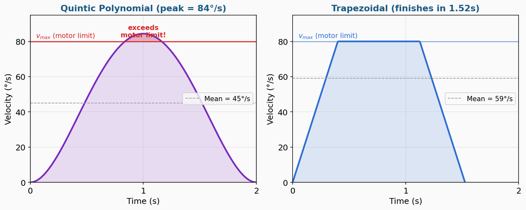

Quintic polynomial can **exceed motor limits** (peak 84°/s > 80°/s) and you can’t control it. Trapezoidal **respects** $v_{max}$ by design, cruises there, and finishes faster.

## From Polynomials to Velocity Profiles

Instead of solving for polynomial coefficients, **design the velocity shape directly** around motor limits ($v_{max}$, $a_{max}$):

- Get to maximum speed as quickly as possible
- Stay there for as long as possible
- Then slow down

This is what **velocity profiles** do — and it’s what industrial controllers use.

## Trapezoidal Velocity Profile

[figure not shown]

**Three phases:** Constant acceleration → constant velocity (cruise) → constant deceleration

**Parameters:** total distance $d$, maximum velocity $v_{max}$, maximum acceleration $a_{max}$

## Trapezoidal Profile: Equations

| Quantity | Formula | Meaning |
| --- | --- | --- |
| Acceleration time | $t_a = \dfrac{v_{max}}{a_{max}}$ | Time to reach cruise speed |
| Acceleration distance | $d_a = \dfrac{1}{2}\, v_{max} \cdot t_a$ | Distance covered during ramp-up (shaded triangle) |
| Cruise time | $t_c = \dfrac{d - 2\,d_a}{v_{max}}$ | Time at constant speed ($2d_a$ = accel + decel distance) |
| Total time | $t_f = 2\,t_a + t_c$ | Ramp-up + cruise + ramp-down |

**Warning**

If $d < 2\,d_a$, there is not enough distance to reach $v_{max}$. The cruise phase disappears and the profile becomes **triangular**.

## Trapezoidal Profile: Implementation

```python
def trapezoidal_profile(d, v_max, a_max, dt=0.01):
    """Generate trapezoidal velocity profile."""
    # Time to accelerate to v_max
    t_a = v_max / a_max

    # Distance during acceleration
    d_a = 0.5 * a_max * t_a**2

    if 2 * d_a > d:
        # Triangular profile (no cruise)
        t_a = np.sqrt(d / a_max)
        v_peak = a_max * t_a
        t_c = 0
    else:
        v_peak = v_max
        t_c = (d - 2*d_a) / v_max

    t_f = 2*t_a + t_c
    # ... generate position/velocity arrays
    return t, pos, vel
```

## Comparing Profiles

| Profile | Smoothness | Computation | Use Case |
| --- | --- | --- | --- |
| Linear | Poor | Simple | Very slow motion |
| Cubic | Good | Simple | General PTP |
| Quintic | Very Good | Moderate | Precise motion |
| Trapezoidal | Moderate | Simple | Fast PTP |

# Part 4: Multi-Segment Trajectories

## Why Multi-Segment?

So far: every trajectory goes from **one point to another** and stops.

- Real tasks need motion through intermediate points **without stopping**
- Stopping at every point wastes time and causes velocity **discontinuities**
- We need to **blend** through via points for continuous motion

In FANUC TP: `FINE` = stop at each point, `CNT` = blend through

## Blending at Via Points

**Without blending** (`FINE`)

- Robot stops at each point
- Velocity drops to zero → discontinuity
- Precise but slow

**With blending** (`CNT`)

- Smooth through via points
- Velocity stays continuous
- Faster, but may miss exact waypoint

[figure not shown]

## Multi-Segment Trajectory with mstraj

```python
import roboticstoolbox as rtb
import numpy as np

# Via points (each row = waypoint), start q0=20
via = np.array([[40], [10], [30]])
q0 = np.array([20])

# Trapezoidal blending: qdmax=1, tacc=2s
traj = rtb.mstraj(via, dt=0.1, tacc=2,
                   qdmax=[1], q0=q0)

# No blending (sharp corners)
traj = rtb.mstraj(via, dt=0.1, tacc=0,
                   qdmax=[1], q0=q0)

# Faster: higher max velocity
traj = rtb.mstraj(via, dt=0.1, tacc=0,
                   qdmax=[2], q0=q0)

# Specify segment durations instead
traj = rtb.mstraj(via, dt=0.1, tacc=4,
                   tsegment=[10, 30, 20], q0=q0)
```

- `via`: waypoints (each row = target), `q0`: start position
- `qdmax`: max velocity per axis, `dt`: time step
- `tacc`: blend time — larger = smoother corners
- `tsegment`: segment durations (overrides `qdmax`)

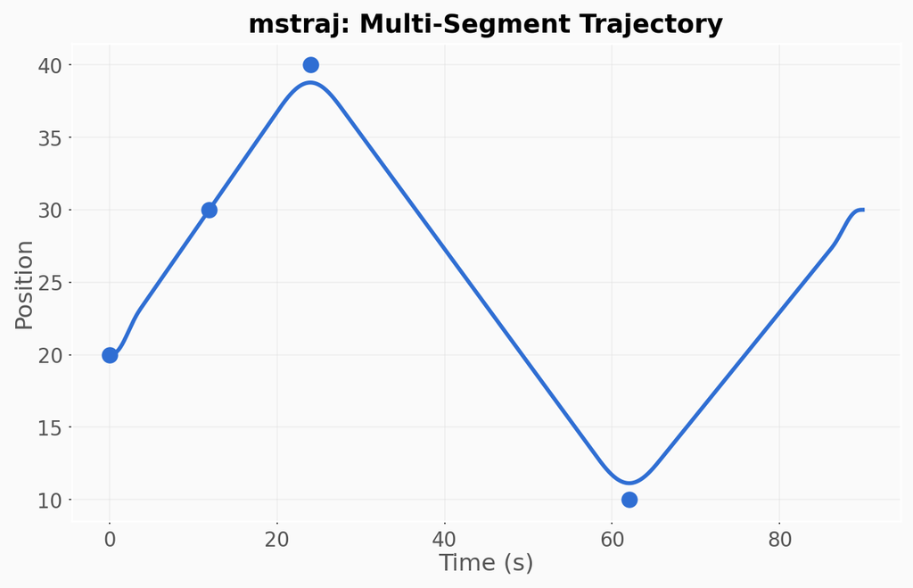

`mstraj` chains trapezoidal-velocity segments between via points and blends at transitions.

## Using roboticstoolbox for Trajectories

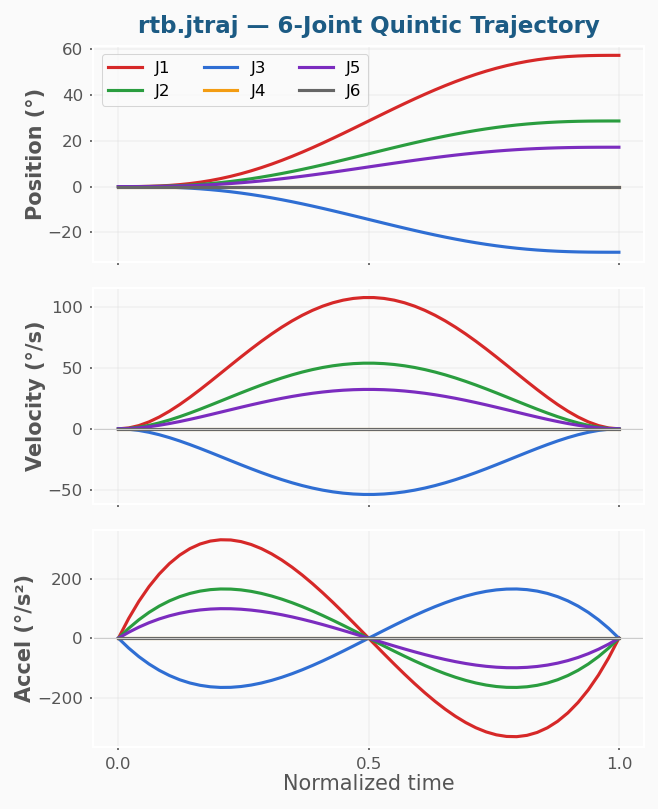

```python
import roboticstoolbox as rtb
import numpy as np

q0 = np.array([0, 0, 0, 0, 0, 0])
qf = np.array([1, 0.5, -0.5, 0, 0.3, 0])

# Quintic joint trajectory
traj = rtb.jtraj(q0, qf, 50)

# Access results
traj.q    # Positions
traj.qd   # Velocities
traj.qdd  # Accelerations

# Plot
import matplotlib.pyplot as plt
plt.plot(traj.q)
plt.show()
```

## Cartesian Trajectory with roboticstoolbox

```python
from spatialmath import SE3

T0 = SE3.Trans(0.4, 0, 0.3)
T1 = SE3.Trans(0.4, 0.2, 0.3)

# Linear position + SLERP orientation
traj = rtb.ctraj(T0, T1, 50)

# traj is a list of SE3 poses
for T in traj:
    print(T.t)  # Translation
```

```
>>> traj[0].t
[0.400, 0.000, 0.300]
>>> traj[25].t
[0.400, 0.100, 0.300]  # halfway
>>> traj[49].t
[0.400, 0.200, 0.300]

>>> traj[0].A
[[1  0  0  0.4]
 [0  1  0  0.0]
 [0  0  1  0.3]
 [0  0  0  1.0]]
```

Y interpolates linearly: 0 → 0.1 → 0.2

# Part 5: Interpolating Orientation (Cartesian Only)

## The Orientation Problem

So far we interpolated **positions**. But a Cartesian pose also includes **orientation**.

**Note**

This section applies to **Cartesian-space** planning only (L motion). Joint-space interpolation (J motion) handles orientation implicitly through FK — no special treatment needed.

Why can’t we just average two rotation matrices?

$$R_{avg} = \frac{R_1 + R_2}{2} \quad \Rightarrow \quad \text{not orthogonal, } \det \neq 1$$

The result is **not a valid rotation**. We need representations that support meaningful interpolation.

## Approach 1: RPY Angle Interpolation

**Simple idea**: Interpolate roll, pitch, yaw independently

$$\phi(t) = \phi_0 + s(t) \cdot (\phi_f - \phi_0)$$

Same for $\theta(t)$ and $\psi(t)$.

**Problem — the direction ambiguity:**

Each angle lives on a circle → two paths from A to B (short way and long way).

## The Direction Problem

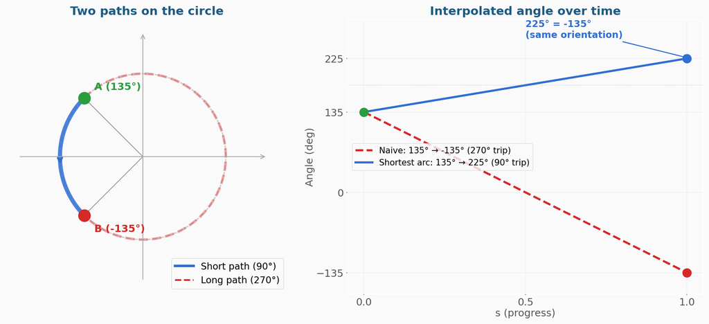

**Warning**

**Fix**: If $|\Delta\phi| > 180°$, add/subtract 360° to take the shortest arc.

## Quaternion Recap: What is a Quaternion?

A quaternion is a **4-component** number: $\;\mathbf{q} = w + x\,\mathbf{i} + y\,\mathbf{j} + z\,\mathbf{k}$

Written as a scalar-vector pair: $\;\mathbf{q} = (w, \;\mathbf{v})$ where $\mathbf{v} = (x, y, z)$

Key rules: $\;\mathbf{i}^2 = \mathbf{j}^2 = \mathbf{k}^2 = \mathbf{i}\mathbf{j}\mathbf{k} = -1$

| Representation | Parameters | Singularities | Interpolation |
| --- | --- | --- | --- |
| Rotation matrix | 9 (6 constraints) | None | Not directly |
| Euler / RPY | 3 | Gimbal lock | Direction problem |
| **Quaternion** | **4 (1 constraint)** | **None** | **SLERP** |

*(See the Quaternion Basics supplementary PDF for full details.)*

## Quaternion Recap: Unit Quaternions = Rotations

A **unit quaternion** ($\|\mathbf{q}\| = 1$) encodes rotation by angle $\theta$ about axis $\hat{\mathbf{k}}$:

$$\mathbf{q} = \left(\cos\frac{\theta}{2},\;\; \sin\frac{\theta}{2}\;\hat{\mathbf{k}}\right)$$

**Examples:**

| Rotation | Quaternion $(w, x, y, z)$ |
| --- | --- |
| Identity (no rotation) | $(1,\; 0,\; 0,\; 0)$ |
| 90° about z-axis | $(\frac{\sqrt{2}}{2},\; 0,\; 0,\; \frac{\sqrt{2}}{2})$ |
| 180° about x-axis | $(0,\; 1,\; 0,\; 0)$ |

Note the **half-angle** $\theta/2$ — both $\mathbf{q}$ and $-\mathbf{q}$ represent the same rotation.

## Quaternion Recap: Operations

**Conjugate** (= inverse rotation for unit quaternions):
$$\mathbf{q}^* = (w, -\mathbf{v})$$

**Multiplication** (composes rotations — order matters):
$$\mathbf{q}_1 \otimes \mathbf{q}_2 = (w_1 w_2 - \mathbf{v}_1 \cdot \mathbf{v}_2,\;\; w_1 \mathbf{v}_2 + w_2 \mathbf{v}_1 + \mathbf{v}_1 \times \mathbf{v}_2)$$

**Rotating a vector** (sandwich product):
$$\mathbf{p}' = \mathbf{q} \otimes (0, \mathbf{p}) \otimes \mathbf{q}^*$$

**In practice**: convert to rotation matrix $R$ and use $\mathbf{p}' = R\,\mathbf{p}$ (faster for many vectors).

| Use case | Best tool |
| --- | --- |
| Store orientation | Quaternion (4 floats, no drift) |
| Interpolate | Quaternion (SLERP) |
| Compose rotations | Quaternion (16 vs 27 multiplications) |
| Rotate vectors | Rotation matrix (9 mult per vector) |

## Approach 2: Quaternion SLERP

**SLERP** (**S**pherical **L**inear Int**erp**olation) — linear interpolation, but on a sphere:

| LERP (on a line) | SLERP (on a sphere) |
| --- | --- |
| $\mathbf{p}(s) = (1-s)\,\mathbf{p}_0 + s\,\mathbf{p}_f$ | $\text{SLERP}(\mathbf{q}_0, \mathbf{q}_f, s) = \frac{\sin((1-s)\Omega)}{\sin\Omega}\,\mathbf{q}_0 + \frac{\sin(s\,\Omega)}{\sin\Omega}\,\mathbf{q}_f$ |
| Weights: $(1-s)$ and $s$ | Weights: $\frac{\sin((1-s)\Omega)}{\sin\Omega}$ and $\frac{\sin(s\,\Omega)}{\sin\Omega}$ |
| Result on the **line** | Result on the **sphere surface** |
| Constant linear speed | Constant angular speed |

where $\Omega = \cos^{-1}(\mathbf{q}_0 \cdot \mathbf{q}_f)$ is half the rotation angle between the two orientations.

## Why SLERP and Not Just LERP?

If you use regular LERP on quaternions: $(1-s)\,\mathbf{q}_0 + s\,\mathbf{q}_f$

- Result falls **inside** the sphere — not a valid unit quaternion
- Speed is **non-uniform** — faster in the middle, slower at the ends

The sin-based weights in SLERP fix both: result stays on the sphere, angular velocity is constant.

**Analogy**: two cities on Earth. LERP digs a tunnel (through the interior). SLERP walks the great circle (shortest path on the surface).

**Tip**

If $\mathbf{q}_0 \cdot \mathbf{q}_f < 0$, negate one quaternion to take the short path (same rotation, shorter arc).

## SLERP vs RPY vs Euler

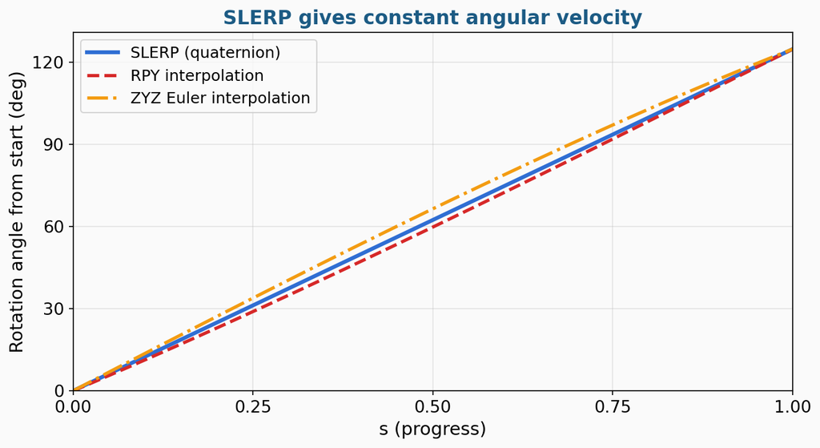

Only SLERP progresses at **constant angular velocity** (straight line). RPY and Euler speed up and slow down unpredictably.

## Practice: SLERP by Hand

**Problem:** Interpolate halfway ($s = 0.5$) between:

- $\mathbf{q}_0 = (1, 0, 0, 0)$ — identity (no rotation)
- $\mathbf{q}_f = (0, 0, 0, 1)$ — 180° about z-axis

**Solution:**

1. Dot product: $\mathbf{q}_0 \cdot \mathbf{q}_f = 1 \times 0 + 0 + 0 + 0 = 0$
2. $\Omega = \cos^{-1}(0) = 90°$ (half the 180° rotation)
3. Weights at $s = 0.5$: $\frac{\sin(0.5 \times 90°)}{\sin 90°} = \frac{\sin 45°}{1} = \frac{\sqrt{2}}{2}$ for both
4. $\mathbf{q}(0.5) = \frac{\sqrt{2}}{2}(1, 0, 0, 0) + \frac{\sqrt{2}}{2}(0, 0, 0, 1) = (\frac{\sqrt{2}}{2}, 0, 0, \frac{\sqrt{2}}{2})$

This is a **90° rotation about z** — exactly halfway, as expected.

## Python: RPY vs SLERP in Practice

```python
from spatialmath import SO3, UnitQuaternion

q0 = UnitQuaternion(
  SO3.RPY([0, 0, 0], unit='deg'))
qf = UnitQuaternion(
  SO3.RPY([60, -30, 45], unit='deg'))

# SLERP trajectory
traj = [q0.interp(qf, s)
        for s in np.linspace(0, 1, 100)]
```

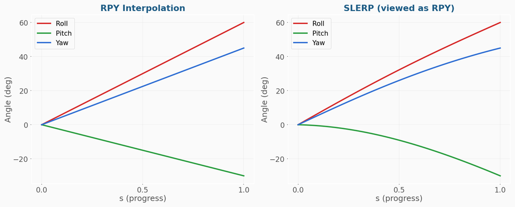

RPY: straight lines (each angle independent). SLERP: coupled curves (geodesic viewed as RPY).

## Full Pose Interpolation with ctraj

```python
T0 = SE3.Trans(0.4, 0, 0.3) * \
     SE3.RPY([0, 0, 0], unit='deg')
Tf = SE3.Trans(0.2, 0.3, 0.5) * \
     SE3.RPY([-90, 45, 60], unit='deg')

traj = rtb.ctraj(T0, Tf, 100)
```

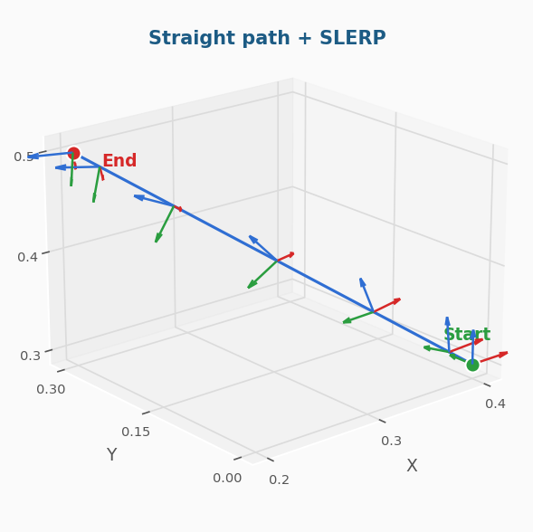

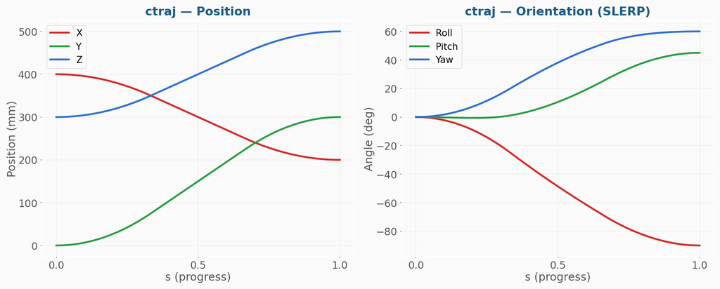

Curves show the **timing profile** (quintic $s(t)$), not the path shape. The spatial path is a straight line (left).

## Joint vs Cartesian Interpolated Motion

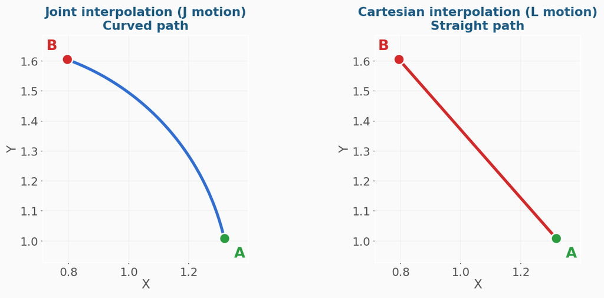

**Joint** (`J` motion)

- Interpolate joint angles directly
- No IK during motion — fast, always feasible
- Cartesian path is **curved**
- Orientation: whatever FK gives

**Cartesian** (`L` motion)

- Straight line + SLERP
- IK at every timestep — may hit singularities
- Path is **straight**
- Orientation: controlled via SLERP

# Part 6: Practical Considerations

## Synchronizing Multiple Joints

**Problem**: Different joints have different distances to travel

**Approach 1: Slowest Joint** (common)

- Find joint with longest travel time
- Scale all other joints to match

**Approach 2: Coordinated Motion**

- All joints reach waypoints simultaneously
- May require different velocity limits per joint

## Joint Limits and Constraints

**Always check:**

1. **Position limits**: $q_{min} \leq q(t) \leq q_{max}$
2. **Velocity limits**: $|\dot{q}(t)| \leq \dot{q}_{max}$
3. **Acceleration limits**: $|\ddot{q}(t)| \leq \ddot{q}_{max}$
4. **Torque limits**: $|\tau(t)| \leq \tau_{max}$

**Scaling**: If limits exceeded, scale time to reduce velocity/acceleration

## Real-Time Trajectory Generation

**Offline Planning**

- Pre-compute entire trajectory
- Store as lookup table
- Execute by playback
- Simple, predictable

**Online Planning**

- Compute trajectory in real-time
- React to sensor feedback
- More complex
- Needed for dynamic environments

**Industrial robots typically use offline planning with minor online adjustments**

## Summary

**Key Concepts:**

1. **Path vs Trajectory**: Path is geometry, trajectory adds timing
2. **Polynomial trajectories**: Cubic for simple, quintic for smooth
3. **Velocity profiles**: Trapezoidal for respecting motor limits
4. **Multi-joint**: Synchronize to slowest joint
5. **Constraints**: Always check limits!

**Next Week:**

- Week 7: Industrial Sensors & Logic
- PLC basics, I/O, and safety systems

## Questions?

[figure not shown]

**Lab this week: FANUC Hardware Introduction!**